# Joe Crowder

2024-12-03

# Introduction

# Data Preparation

```r
library(tidyverse) # run at the beginning of every session.
```

```r
library(readr)
library(dplyr)
library(ggplot2)
options(scipen=999)

#Cybersecurity breaches reported to the US Department of Health and Human Services
SecurityBreaches <- read_csv("HHSCyberSecurityBreaches.csv")
SecurityBreachesCleaned <- read_csv("HHSCyberSecurityBreachesCleaned.csv")
```

A glimpse at our dataset

```r
glimpse(SecurityBreachesCleaned)
```

```
## Rows: 1,151
## Columns: 10
## $ rownames                         <dbl> 137, 168, 235, 344, 569, 599, 693, 70…
## $ Name.of.Covered.Entity           <chr> "UNCG Speech and Hearing Center", "Un…
## $ State                            <chr> "NC", "OK", "MO", "WI", "HI", "TX", "…
## $ Covered.Entity.Type              <chr> "Healthcare Provider", "Healthcare Pr…
## $ Individuals.Affected             <dbl> 2300, 19200, 800, 3000, 674, 2988, 27…
## $ Breach.Submission.Date           <chr> "8/9/2010", "9/27/2010", "2/10/2011",…
## $ Type.of.Breach                   <chr> "Hacking/IT Incident", "Hacking/IT In…
## $ Location.of.Breached.Information <chr> "Desktop Computer", "Desktop Computer…
## $ Business.Associate.Present       <lgl> FALSE, FALSE, FALSE, TRUE, FALSE, FAL…
## $ Web.Description                  <chr> "\\N", "\\N", "\\N", "\\N", "\\N", "\…
```

Data Manipulation/Cleaning

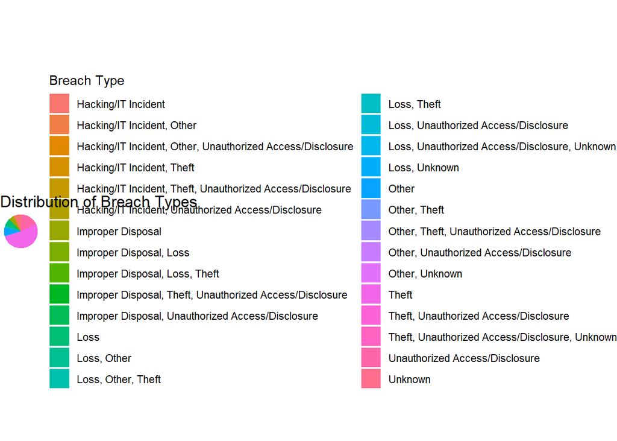

```r
#An issue I came across when trying to plot the distribution of Breach Types (Type.of.Breach) lead to the data needing to be cleaned in Excel prior to importing
library(ggplot2)
breach_counts <- SecurityBreaches %>%
  count(Type.of.Breach) %>%
  mutate(percentage = n / sum(n) * 100)

ggplot(breach_counts, aes(x = "", y = percentage, fill = Type.of.Breach)) +
  geom_bar(stat = "identity", width = 1) +
  coord_polar(theta = "y") +
  labs(title = "Distribution of Breach Types",
       fill = "Breach Type") +
  theme_void()
```

# Exploratory Data Analysis and Visualization

Top 10 Organizations with the most affected individuals?

```r
top10_entities <- SecurityBreachesCleaned %>%
  group_by(Name.of.Covered.Entity) %>%
  summarise(Total.Affected = sum(Individuals.Affected, na.rm = TRUE)) %>%
  arrange(desc(Total.Affected)) %>% head(10)
print(top10_entities)
```

```
## # A tibble: 10 × 2
##    Name.of.Covered.Entity                                         Total.Affected
##    <chr>                                                                   <dbl>
##  1 Science Applications International Corporation (SA                    4900000
##  2 Community Health Systems Professional Services Corporation            4500000
##  3 Advocate Health and Hospitals Corporation, d/b/a Advocate Med…        4029530
##  4 Xerox State Healthcare, LLC                                           2000000
##  5 IBM                                                                   1900000
##  6 GRM Information Management Services                                   1700000
##  7 AvMed, Inc.                                                           1220000
##  8 Montana Department of Public Health and Human Services                1062509
##  9 The Nemours Foundation                                                1055489
## 10 BlueCross BlueShield of Tennessee, Inc.                               1023209
```

Number of Data Breaches By Type

```r
NumberofBreaches <- SecurityBreachesCleaned %>%
  group_by(Type.of.Breach) %>%
  summarise(Total.Affected = n(), .groups = 'drop') %>% arrange(desc(Total.Affected))
print(NumberofBreaches)
```

```
## # A tibble: 7 × 2
##   Type.of.Breach                 Total.Affected
##   <chr>                                   <int>
## 1 Theft                                     602
## 2 Unauthorized Access/Disclosure            184
## 3 Loss                                      105
## 4 Other                                     105
## 5 Hacking/IT Incident                        94
## 6 Improper Disposal                          51
## 7 Unknown                                    10
```

Occurences of Theft are quite large compared to the runner up. However, this may not indicate the number of individuals affected.

Lets see if we can try to clarify what the “Unknown” and “Other” Breaches might be. What might the “Other” data breaches entail?

Top 10 most affected “Other” data breaches:

```r
top_10_Other_breaches <- SecurityBreachesCleaned %>%
filter(Type.of.Breach == "Other") %>% group_by(Web.Description) %>% summarise(total_affected = sum(Individuals.Affected, na.rm = TRUE)) %>%
  arrange(desc(total_affected)) %>%
  head(10)
print(top_10_Other_breaches)
```

```
## # A tibble: 10 × 2
##    Web.Description                                                total_affected
##    <chr>                                                                   <dbl>
##  1 "\\N"                                                                 1353159
##  2 "In its breach report and during the course of OCR\u001a\u001…          83000
##  3 "The business associate prepared a document as part of a requ…          22642
##  4 "Paper correspondence to certain members in UnitedHealth\u001…          16291
##  5 "The covered entity sent postcards to approximately 3,800 pat…           3800
##  6 "An employee of the covered entity emailed protected health i…           2416
##  7 "On June 11, 2010, a laptop computer containing PHI was mista…           1309
##  8 "A business associate employee sent an email to multiple pati…            937
##  9 "Protected health information was attached to an email addres…            692
## 10 "Social security numbers were inadvertently printed on the ad…            560
```

Many of these do fall into already established categories but need an individual to filter them one by one.

The “Unknown” Breaches

```r
top_10_Unknown_breaches <- SecurityBreachesCleaned %>%

  filter(Type.of.Breach == "Unknown") %>% group_by(Web.Description) %>% summarise(total_affected = sum(Individuals.Affected, na.rm = TRUE)) %>%
  arrange(desc(total_affected)) %>%
  head(10)
print(top_10_Unknown_breaches)
```

```
## # A tibble: 3 × 2
##   Web.Description                                                 total_affected
##   <chr>                                                                    <dbl>
## 1 "\\N"                                                                  1917106
## 2 "The IT department turned on the switch to a BA HIE without no…            654
## 3 "A newly hired employee impermissibly took patient registratio…            551
```

Seems we only have two descriptions for our Unknown Breaches.

Distribution of Data Breach Types?

[figure not shown]

```r
Date_of_Breach1 <- SecurityBreachesCleaned %>%
  group_by(Type.of.Breach) %>%
  summarise(Count = n(), .groups = 'drop')
ggplot(Date_of_Breach1, aes(x = reorder(Type.of.Breach, -Count), y = Count, fill = Type.of.Breach)) +
  geom_bar(stat = "identity") +
  labs(title = "Count of Breaches by Type", x = "Type of Breach", y = "Individuals Affected") +
  theme_minimal() +
  theme(axis.text.x = element_text(angle = 45, hjust = 1)) + geom_text(aes(label = Count), vjust = -0.25, size = 3, color = "black")
```

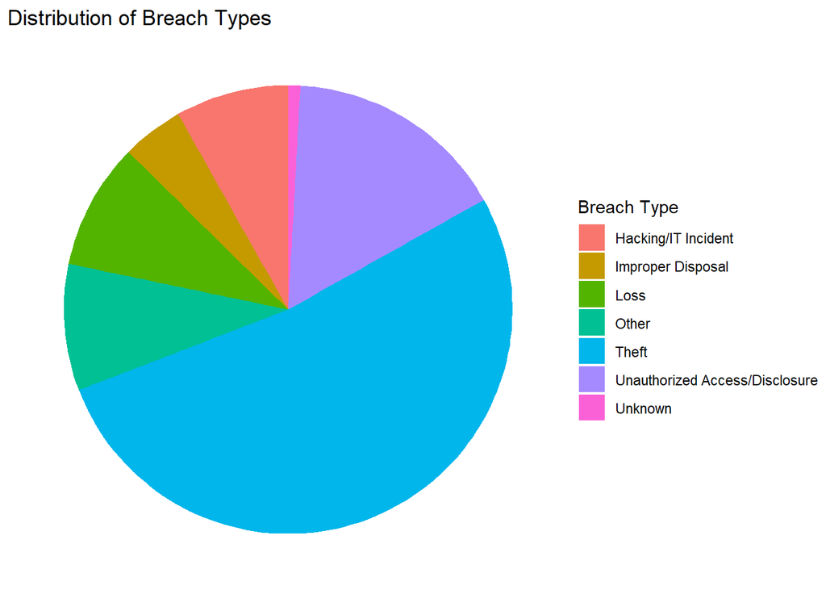

```r
breach_counts <- SecurityBreachesCleaned %>%
  count(Type.of.Breach) %>%
  mutate(percentage = n / sum(n) * 100)
ggplot(breach_counts, aes(x = "", y = percentage, fill = Type.of.Breach)) +
  geom_bar(stat = "identity", width = 1) +
  coord_polar(theta = "y") +
  labs(title = "Distribution of Breach Types",
       fill = "Breach Type") +
  theme_void()
```

Top 10 most affected states

```r
top10_states <- SecurityBreachesCleaned %>%
  group_by(State) %>%
  summarise(Total.Affected = sum(Individuals.Affected, na.rm = TRUE)) %>%
  arrange(desc(Total.Affected)) %>%
  head(10)
print(top10_states)
```

```
## # A tibble: 10 × 2
##    State Total.Affected
##    <chr>          <dbl>
##  1 TN           6125371
##  2 VA           5148257
##  3 IL           4602939
##  4 TX           3492300
##  5 NJ           3035497
##  6 FL           2931504
##  7 NY           2758702
##  8 CA           2422097
##  9 PR           1234508
## 10 PA           1219266
```

```r
GraphTopStates <- ggplot(top10_states, aes(x = reorder(State, Total.Affected), y = Total.Affected)) +
  geom_bar(stat = "identity", fill = "salmon") +
  theme_minimal() +
  labs(title = "Top 10 States by Individuals Affected", x = "State", y = "Individuals Affected") +
  theme(axis.text.x = element_text(angle = 0, hjust = 1))
```

# Individuals Affected by States

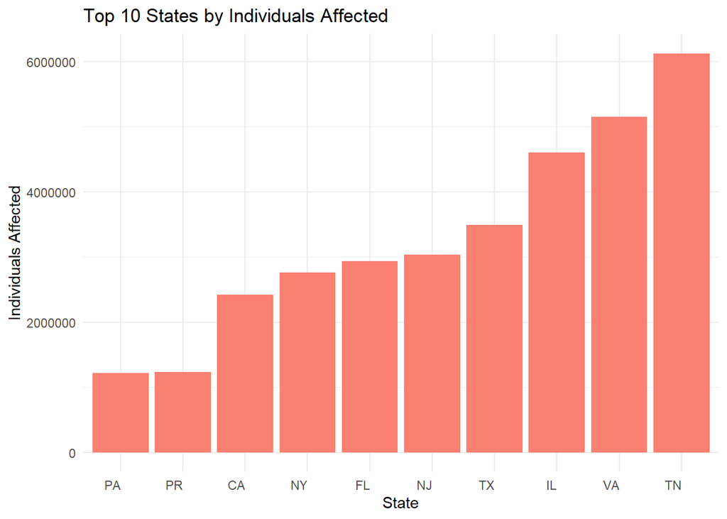

```r
print(GraphTopStates)
```

# What is the average number of affected indivduals by breach type

```r
AverageIndividualAffected <- SecurityBreachesCleaned %>%
group_by(Type.of.Breach) %>%
summarise(Average.Affected = mean(Individuals.Affected, na.rm = TRUE)) %>%
arrange(desc(Average.Affected))
print(AverageIndividualAffected)
```

```
## # A tibble: 7 × 2
##   Type.of.Breach                 Average.Affected
##   <chr>                                     <dbl>
## 1 Unknown                                 191831.
## 2 Loss                                     70868.
## 3 Hacking/IT Incident                      40091.
## 4 Theft                                    36183.
## 5 Unauthorized Access/Disclosure           21819.
## 6 Improper Disposal                        15115.
## 7 Other                                    14146.
```

Despite Theft occuring nearly three times more than the next most occuring breach (Unauthorized Access) remains as the 4th breach the highest average of individuals affected.

# Which date had the most individuals affected

```r
WorstBreachDate <- SecurityBreachesCleaned %>%
  group_by(Type.of.Breach) %>% slice(which.max(Individuals.Affected)) %>%
  select(Type.of.Breach, Worst_Date = Breach.Submission.Date, Individuals.Affected, Name.of.Covered.Entity) %>%
  arrange(desc(Individuals.Affected)) %>% head(15)
print(WorstBreachDate)
```

```
## # A tibble: 7 × 4
## # Groups:   Type.of.Breach [7]
##   Type.of.Breach          Worst_Date Individuals.Affected Name.of.Covered.Entity
##   <chr>                   <chr>                     <dbl> <chr>
## 1 Loss                    11/4/2011               4900000 Science Applications …
## 2 Theft                   8/20/2014               4500000 Community Health Syst…
## 3 Unauthorized Access/Di… 9/10/2014               2000000 Xerox State Healthcar…
## 4 Unknown                 4/14/2011               1900000 IBM
## 5 Hacking/IT Incident     7/7/2014                1062509 Montana Department of…
## 6 Other                   4/18/2012                315000 Emory Healthcare
## 7 Improper Disposal       7/11/2013                277014 Shred-it Internationa…
```

# Lets take a look at where the data from these breaches originally came from.

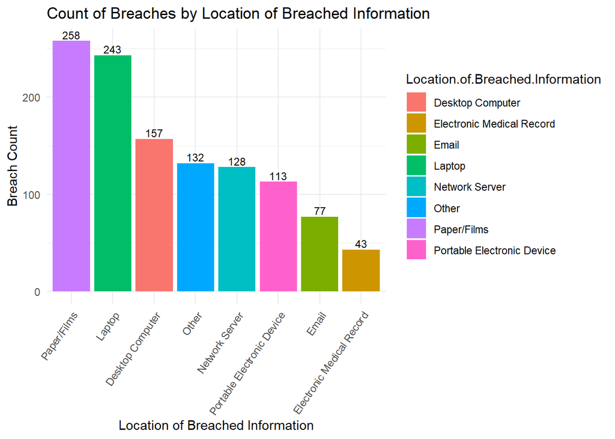

```r
BreachedLocations <- SecurityBreachesCleaned %>%
  group_by(Location.of.Breached.Information) %>%
  summarise(Count = n(), .groups = 'drop')
ggplot(BreachedLocations, aes(x = reorder(Location.of.Breached.Information, -Count), y = Count, fill = Location.of.Breached.Information)) +
  geom_bar(stat = "identity") +
  geom_text(aes(label = Count), vjust = -0.25, size = 3, color = "black") +
  labs(title = "Count of Breaches by Location of Breached Information",
       x = "Location of Breached Information", y = "Breach Count") +
  theme_minimal() +
  theme(axis.text.x = element_text(angle = 55, hjust = 1))
```

[figure not shown]

```r
library(ggplot2)
LocationBreaches <- SecurityBreachesCleaned %>%
  count(Location.of.Breached.Information) %>%
  mutate(percentage = n / sum(n) * 100)
ggplot(LocationBreaches, aes(x = "", y = percentage, fill = Location.of.Breached.Information)) +
  geom_bar(stat = "identity", width = 1) +
  coord_polar(theta = "y") +
  labs(title = "Distribution of Breach Types",
       fill = "Breach Type") +
  theme_void()
```

Graphing with respect to time?

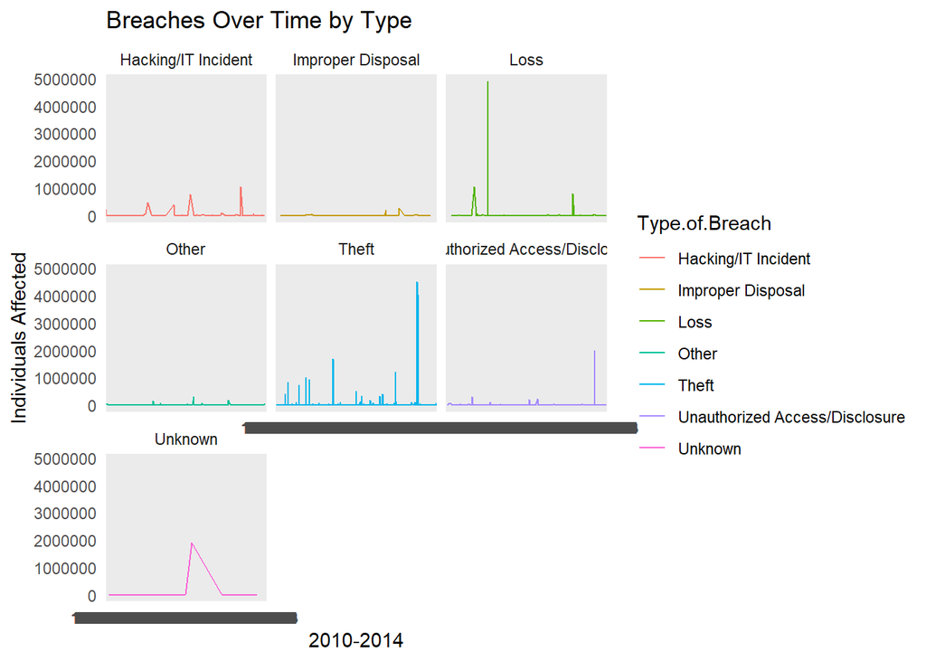

```r
ggplot(SecurityBreachesCleaned, aes(x = Breach.Submission.Date, y = Individuals.Affected, color = Type.of.Breach, group = Type.of.Breach)) +
  geom_line() +
  labs(title = "Breaches Over Time by Type", x = "2010-2014", y = "Individuals Affected") +
  theme_minimal() +
  facet_wrap(~Type.of.Breach)
```

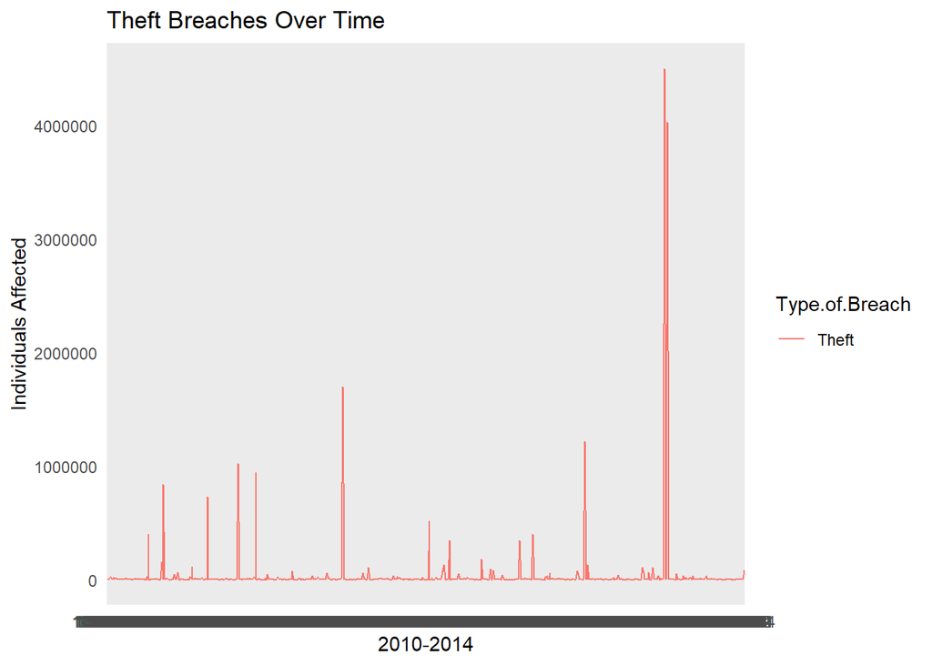

```r
Theft_breach_data <- SecurityBreachesCleaned %>%
  filter(Type.of.Breach == "Theft")

# Create the plot for the filtered data
ggplot(Theft_breach_data, aes(x = Breach.Submission.Date, y = Individuals.Affected, color = Type.of.Breach, group = Type.of.Breach)) +
  geom_line() +
  labs(title = "Theft Breaches Over Time",
       x = "2010-2014",
       y = "Individuals Affected") +
  theme_minimal()
```

# Summary

One of the key insights from this analysis is the variance in the number of individuals affected by different breach types. For example, breaches related to Loss often resulted in a higher number of affected individuals compared to other types, such as Unauthorized Access or Hacking Incidences. This suggests that while some breach types may be more common, they may not necessarily have the same widespread impact.

We also found that breaches involving Lost Items are particularly prone to affecting large numbers of individuals. This highlights the need for organizations to implement better access control, and regular security audits to protect sensitive patient information from being leaked.

A notable limitation of this analysis was the lack of detailed information on the effectiveness of specific cybersecurity measures implemented by the organizations. Knowing the resources dedicated to cybersecurity, including investment in training and technology, could provide a clearer picture of how preventative actions might reduce the frequency and severity of breaches.

Ultimately, our findings suggest that while healthcare organizations are increasingly reporting cybersecurity breaches, there are opportunities to reduce their frequency and mitigate their impact. Investing in robust security systems, regular risk assessments, and comprehensive staff training are essential steps toward improving the protection of sensitive healthcare data.